# Right Ventricular Mortality Analysis

Samuel Ash

2018-12-10

# Overview

Mortality and exacerbation analyses including stratified by right ventricular volume and by arterial pruning.

## Load Libraries and Data

### Libraries

1. tidyverse
2. survival
3. survminer
4. cowplot
5. readxl
6. naniar
7. janitor
8. kableExtra
9. broman (with addition of myround2 by Karl Broman)
10. pscl
11. MASS

```r
library(tidyverse)
library(survival)
library(survminer)
library(cowplot)
library(readxl)
library(naniar)
library(janitor)
library(kableExtra)
library(broman)
library(pscl)
library(MASS)
```

```r
myround2 <- function(x, digits = 3){
  if (x < 10^-digits) return(paste('<', 10^-digits))
  paste('=', myround(x, digits))
}
```

### Data

1. Abbreviated RV, pruning and mortality data from GRW dated July 25, 2018.
2. COPDGene clinical data from October 2017
3. COPGene LFU from July 2018

```r
RV_raw = read_excel("../data/RV size by arterial pruning and survival.xlsx")
clinical_data_pre <- read_delim("../data/COPDGene_P1P2_All_Visit_09OCT17.txt",
    "\t", escape_double = FALSE, trim_ws = TRUE)
```

### Additional Notes regarding these datasets

1. Those who are pruned (those with aBV5 < median) have arterial_prune=1 and those that are not pruned (aBV5 > median) have arterial_prune=0
2. Those that have RV_vol=1 are those with large right ventricles (highest quartile) and those with with RV_vol=0 have small right ventricles

### Data cleaning:

1. Remove all rows with NA
2. Change vital status and days followed to numeric
3. Merge with clinical data
4. Merge with LFU

```r
# change . to NA and remove those rows
RV_proc <- RV_raw %>% na_if(".") %>% na.omit()
# change days followed and vital status to numeric
RV_proc$days_followed <- as.numeric(RV_proc$days_followed)
RV_proc$years_mortality <- RV_proc$days_followed/365
RV_proc$vital_status <- as.numeric(RV_proc$vital_status)

# clinical dataset
clinical_data_pre1 <- clean_names(clinical_data_pre)
clinical_data_pre2 <- clinical_data_pre1 %>%
  filter(visitnum==1) %>%
  dplyr::select(sid,age_enroll,gender,race,bmi,fev1pp_utah,pct_emph_slicer,ccenter,smok_cig_now,ats_pack_years,exacerbation_frequency,sgrq_score_total,gastro_esoph_reflx) %>%
  mutate(priorexacerbation = ifelse(exacerbation_frequency > 0, 1, 0))

RV_clin <- inner_join(RV_proc,clinical_data_pre2)

# LFU
lfu_pre1 <- read_delim("../data/LFU_SidLevel_w_Comorbid_31JUL18.txt",
    "\t", escape_double = FALSE, trim_ws = TRUE)
lfu_pre2 <- clean_names(lfu_pre1)

rv_clin_lfu <- inner_join(RV_clin,lfu_pre2,by="sid")
```

# Analysis

## Survival

### Effect of pruning in the entire cohort - Kaplan Meier

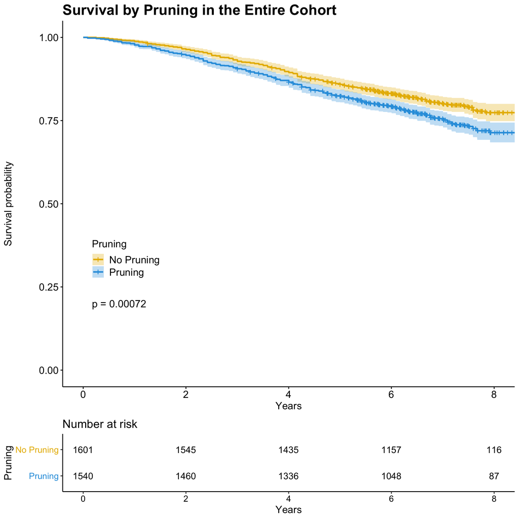

```r
KMPrune.allRV <- survfit(Surv(years_mortality, vital_status) ~ arterial_prune, data=RV_proc)
KMPrune.allRV.p = as.matrix(surv_pvalue(KMPrune.allRV, method = "survdiff", test.for.trend = FALSE, combine = FALSE)[,2])
surv.km.prune.allRV <- ggsurvplot(KMPrune.allRV, data=RV_proc, risk.table = TRUE,
                                  pval = TRUE, conf.int = TRUE,
                                  risk.table.y.text.col = T, risk.table.y.text = TRUE,
                            legend = c(0.14,0.35), legend.title="Pruning",
                            legend.labs=c("No Pruning","Pruning"),
                            risk.table.height = 0.2,
                            palette=c("#E7B800", "#2E9FDF"),
                            title="Survival by Pruning in the Entire Cohort",
                            font.legend=c(14), font.title=c(20, "bold"),
                            font.x=c(14), font.y=c(14), font.tickslab=c(14),
                            xlab="Years")
surv.km.prune.allRV
```

### Effect of pruning in the entire cohort - Cox

```r
# univariate
cox_prune_all_RV_uni <- coxph(Surv(years_mortality, vital_status) ~ arterial_bv5, data=RV_proc)
cox_prune_all_RV_uni_table <- cbind(exp(-coef(cox_prune_all_RV_uni)[1]),
                                      exp(-confint(cox_prune_all_RV_uni)[1,2]),
                                      exp(-confint(cox_prune_all_RV_uni)[1,1]),
                                      (summary(cox_prune_all_RV_uni)[[7]][1,5]))


# multivariable
cox_prune_all_RV_multi <- coxph(Surv(years_mortality, vital_status) ~ arterial_bv5 +
                                  age_enroll + gender + race + bmi + fev1pp_utah + pct_emph_slicer + smok_cig_now + ats_pack_years + ccenter, data=RV_clin)
cox_prune_all_RV_multi_table <- cbind(exp(-coef(cox_prune_all_RV_multi)[1]),
                                      exp(-confint(cox_prune_all_RV_multi)[1,2]),
                                      exp(-confint(cox_prune_all_RV_multi)[1,1]),
                                      (summary(cox_prune_all_RV_multi)[[7]][1,5]))

# table with both univariate and multivariable
cox_prune_all_RV_both_table <- rbind(cox_prune_all_RV_uni_table,cox_prune_all_RV_multi_table)
row.names(cox_prune_all_RV_both_table) <- c("Univariate","Multivariable")
kable(cox_prune_all_RV_both_table,
      row.names = TRUE,
      col.names = c("Hazard Ratio","Lower Limit","Upper Limit","p"),
      align="c",digits=c(3,3,3,7)) %>%
  add_header_above(c(" "=2,"Confidence Interval"=2," "=1)) %>%
  kable_styling(bootstrap_options = "striped", full_width = F) %>%
  footnote(number=c("Hazard Ratio Expressed per 1mL decrease in BV5 in the entire cohort",
                    "Multivarible analysis adjusted for age, sex, race, smoking status, pack years, BMI, FEV1%, LAA% and clinical center"))
```

|  | Hazard Ratio | Confidence Interval Lower Limit | Confidence Interval Upper Limit | p |
| --- | --- | --- | --- | --- |
| Univariate | 1.008 | 1.005 | 1.011 | 0.0000004 |
| Multivariable | 1.006 | 1.002 | 1.011 | 0.0035452 |

<sup>1</sup> Hazard Ratio Expressed per 1mL decrease in BV5 in the entire cohort  
<sup>2</sup> Multivarible analysis adjusted for age, sex, race, smoking status, pack years, BMI, FEV1%, LAA% and clinical center

### Effect of pruning in the subgroups with and without big right ventricles - Kaplan Meier

```r
KMPrune.bigRV <- survfit(Surv(years_mortality, vital_status) ~ arterial_prune, data=filter(RV_proc,RV_vol==1))
KMPrune.bigRV.p = as.matrix(surv_pvalue(KMPrune.bigRV, method = "survdiff", test.for.trend = FALSE, combine = FALSE)[,2])
surv.km.prune.bigRV <- ggsurvplot(KMPrune.bigRV, data=filter(RV_proc,RV_vol==1), risk.table = TRUE,
                                  pval = TRUE, conf.int = TRUE,
                                  risk.table.y.text.col = T, risk.table.y.text = TRUE,
                            legend = c(0.14,0.35), legend.title="Pruning",
                            legend.labs=c("No Pruning","Pruning"),
                            risk.table.height = 0.2,
                            palette=c("#E7B800", "#2E9FDF"),
                            title="Survival by Pruning in those with Large Right Ventricles",
                            font.legend=c(14), font.title=c(20, "bold"),
                            font.x=c(14), font.y=c(14), font.tickslab=c(14),
                            xlab="Years")
```

```r
KMPrune.otherRV <- survfit(Surv(years_mortality, vital_status) ~ arterial_prune, data=filter(RV_proc,RV_vol==0))
KMPrune.otherRV.p = as.matrix(surv_pvalue(KMPrune.otherRV, method = "survdiff", test.for.trend = FALSE, combine = FALSE)[,2])
surv.km.prune.otherRV <- ggsurvplot(KMPrune.otherRV, data=filter(RV_proc,RV_vol==0), risk.table = TRUE,
                                  pval = TRUE, conf.int = TRUE,
                                  risk.table.y.text.col = T, risk.table.y.text = TRUE,
                            legend = c(0.14,0.35), legend.title="Pruning",
                            legend.labs=c("No Pruning","Pruning"),
                            risk.table.height = 0.2,
                            palette=c("#E7B800", "#2E9FDF"),
                            title="Survival by Pruning in those without Large Right Ventricles",
                            font.legend=c(14), font.title=c(20, "bold"),
                            font.x=c(14), font.y=c(14), font.tickslab=c(14),
                            xlab="Years")
```

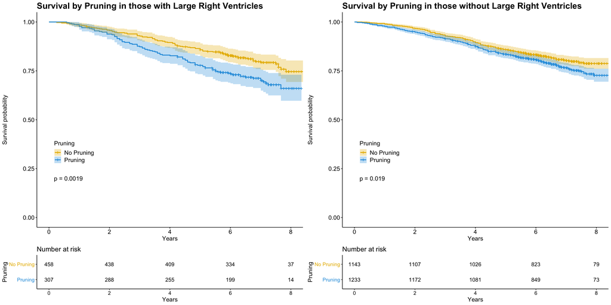

```r
# plot
rv.plots <- list(surv.km.prune.bigRV, surv.km.prune.otherRV)

# Arrange multiple ggsurvplots and print the output
arrange_ggsurvplots(rv.plots, print = TRUE, ncol = 2, nrow = 1)
```

### Effect of RV size only - Kaplan Meier

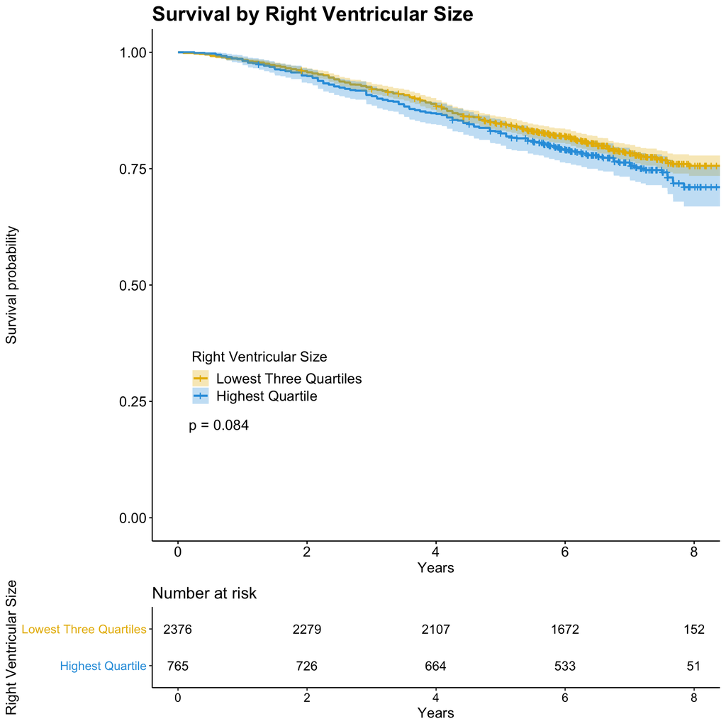

```r
KMRV <- survfit(Surv(years_mortality, vital_status) ~ RV_vol, data=RV_proc)
surv.km.RV <- ggsurvplot(KMRV, data=RV_proc, risk.table = TRUE, pval = TRUE,
                            conf.int = TRUE,
                            risk.table.y.text.col = T, risk.table.y.text = TRUE,
                            legend = c(0.22,0.32), legend.title="Right Ventricular Size",
                            legend.labs=c("Lowest Three Quartiles","Highest Quartile"),
                            risk.table.height = 0.2,
                            palette=c("#E7B800", "#2E9FDF"),
                            title="Survival by Right Ventricular Size",
                            font.legend=c(14), font.title=c(20, "bold"),
                            font.x=c(14), font.y=c(14), font.tickslab=c(14),
                            xlab="Years")
surv.km.RV
```

```r
KMRV.p = as.matrix(surv_pvalue(KMRV, method = "survdiff", test.for.trend = FALSE, combine = FALSE)[,2])
```

### Effect of RV size only - Cox

```r
# univariate
cox_RV_uni <- coxph(Surv(years_mortality, vital_status) ~ RV_EPI_Volume, data=RV_proc)
cox_RV_uni_table <- cbind(exp(coef(cox_RV_uni)[1]),
                              exp(confint(cox_RV_uni)[1,1]),
                              exp(confint(cox_RV_uni)[1,2]),
                              (summary(cox_RV_uni)[[7]][1,5]))


# multivariable
cox_RV_multi <- coxph(Surv(years_mortality, vital_status) ~ RV_EPI_Volume +
                                  age_enroll + gender + race + bmi + fev1pp_utah + pct_emph_slicer + smok_cig_now + ats_pack_years + ccenter, data=RV_clin)
cox_RV_multi_table <- cbind(exp(coef(cox_RV_multi)[1]),
                            exp(confint(cox_RV_multi)[1,1]),
                            exp(confint(cox_RV_multi)[1,2]),
                            (summary(cox_RV_multi)[[7]][1,5]))

# table with both univariate and multivariable
cox_RV_both_table <- rbind(cox_RV_uni_table,cox_RV_multi_table)
row.names(cox_RV_both_table) <- c("Univariate","Multivariable")
kable(cox_RV_both_table,
      row.names = TRUE,
      col.names = c("Hazard Ratio","Lower Limit","Upper Limit","p"),
      align="c",digits=c(3,3,3,8)) %>%
  add_header_above(c(" "=2,"Confidence Interval"=2," "=1)) %>%
  kable_styling(bootstrap_options = "striped", full_width = F) %>%
  footnote(number=c("Hazard Ratio Expressed per 1mL Increase in right rentricular volume in the Entire Cohort",
                    "Multivarible analysis adjusted for age, sex, race, BMI, smoking status, pack years, FEV1%, LAA% and clinical center"))
```

|  | Hazard Ratio | Confidence Interval Lower Limit | Confidence Interval Upper Limit | p |
| --- | --- | --- | --- | --- |
| Univariate | 1.003 | 1.001 | 1.006 | 0.00303209 |
| Multivariable | 1.008 | 1.005 | 1.010 | 0.00000001 |

<sup>1</sup> Hazard Ratio Expressed per 1mL Increase in right rentricular volume in the Entire Cohort  
<sup>2</sup> Multivarible analysis adjusted for age, sex, race, BMI, smoking status, pack years, FEV1%, LAA% and clinical center

### Effect of right ventricular size in the subgroups with and without pruning - Kaplan Meier

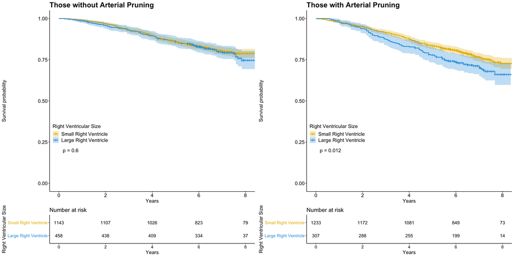

```r
# in those without pruning
KMRV.noprune <- survfit(Surv(years_mortality, vital_status) ~ RV_vol, data=filter(RV_proc,arterial_prune==0))
surv.km.RV.noprune <- ggsurvplot(KMRV.noprune, data=filter(RV_proc,arterial_prune==0),
                                 risk.table = TRUE, pval = TRUE, conf.int = TRUE,
                                 risk.table.y.text.col = T, risk.table.y.text = TRUE,
                            legend = c(0.15,0.32), legend.title="Right Ventricular Size",
                            legend.labs=c("Small Right Ventricle","Large Right Ventricle"),
                            risk.table.height = 0.2,
                            palette=c("#E7B800", "#2E9FDF"),
                            title="Those without Arterial Pruning",
                            font.legend=c(14), font.title=c(20, "bold"),
                            font.x=c(14), font.y=c(14), font.tickslab=c(14),
                            xlab="Years")
KMRV.noprune.p = as.matrix(surv_pvalue(KMRV.noprune, method = "survdiff", test.for.trend = FALSE, combine = FALSE)[,2])

# in those with purning
KMRV.prune <- survfit(Surv(years_mortality, vital_status) ~ RV_vol, data=filter(RV_proc,arterial_prune==1))
surv.km.RV.prune <- ggsurvplot(KMRV.prune, data=filter(RV_proc,arterial_prune==1), risk.table = TRUE,
                                  pval = TRUE, conf.int = TRUE,
                                  risk.table.y.text.col = T, risk.table.y.text = TRUE,
                            legend = c(0.15,0.32), legend.title="Right Ventricular Size",
                            legend.labs=c("Small Right Ventricle","Large Right Ventricle"),
                            risk.table.height = 0.2,
                            palette=c("#E7B800", "#2E9FDF"),
                            title="Those with Arterial Pruning",
                            font.legend=c(14), font.title=c(20, "bold"),
                            font.x=c(14), font.y=c(14), font.tickslab=c(14),
                            xlab="Years")
KMRV.prune.p = as.matrix(surv_pvalue(KMRV.prune, method = "survdiff", test.for.trend = FALSE, combine = FALSE)[,2])

# plot
prune.plots <- list(surv.km.RV.noprune, surv.km.RV.prune)

# Arrange multiple ggsurvplots and print the output
arrange_ggsurvplots(prune.plots, print = TRUE, ncol = 2, nrow = 1)
```

## Exacerbations

### Pruning

```r
### multivariable zero inflated negative binomial regression
# entire cohort
rv_clin_lfu <- rv_clin_lfu %>%
  mutate(lyears = ifelse(years_followed>0, log(years_followed), 0)) %>%
  filter(years_followed > 0)

rate_exac_multi_pruning_all <- zeroinfl(total_exacerbations ~ arterial_prune + age_enroll + gender + race + smok_cig_now + bmi + ats_pack_years +
                              fev1pp_utah + priorexacerbation + sgrq_score_total + pct_emph_slicer + gastro_esoph_reflx, data=rv_clin_lfu,
                              dist="negbin", offset=lyears, EM=TRUE)

rate_exac_multi_pruning_all_table <- cbind(exp(summary(rate_exac_multi_pruning_all)[[1]][[1]][2,1]),
                                           exp(confint(rate_exac_multi_pruning_all)[2,1]),
                                           exp(confint(rate_exac_multi_pruning_all)[2,2]),
                                           (summary(rate_exac_multi_pruning_all)[[1]][[1]][2,4]))

# those with RV enlargement (top quartile)
rate_exac_multi_pruning_RVlarge <- zeroinfl(total_exacerbations ~ arterial_prune + age_enroll + gender + race + smok_cig_now + bmi + ats_pack_years +
                              fev1pp_utah + priorexacerbation + sgrq_score_total + pct_emph_slicer + gastro_esoph_reflx, data=filter(rv_clin_lfu,RV_vol==1),
                              dist="negbin", offset=lyears, EM=TRUE)

rate_exac_multi_pruning_RVlarge_table <- cbind(exp(summary(rate_exac_multi_pruning_RVlarge)[[1]][[1]][2,1]),
                                           exp(confint(rate_exac_multi_pruning_RVlarge)[2,1]),
                                           exp(confint(rate_exac_multi_pruning_RVlarge)[2,2]),
                                           (summary(rate_exac_multi_pruning_RVlarge)[[1]][[1]][2,4]))

# those without RV enlargement
rate_exac_multi_pruning_RVother <- zeroinfl(total_exacerbations ~ arterial_prune + age_enroll + gender + race + smok_cig_now + bmi + ats_pack_years +
                              fev1pp_utah + priorexacerbation + sgrq_score_total + pct_emph_slicer + gastro_esoph_reflx, data=filter(rv_clin_lfu,RV_vol==0),
                              dist="negbin", offset=lyears, EM=TRUE)

rate_exac_multi_pruning_RVother_table <- cbind(exp(summary(rate_exac_multi_pruning_RVother)[[1]][[1]][2,1]), # note reversal for low versus high BV5
                                           exp(confint(rate_exac_multi_pruning_RVother)[2,1]),
                                           exp(confint(rate_exac_multi_pruning_RVother)[2,2]),
                                           (summary(rate_exac_multi_pruning_RVother)[[1]][[1]][2,4]))

rate_exac_multi_pruning_table <- rbind(rate_exac_multi_pruning_all_table,rate_exac_multi_pruning_RVlarge_table,rate_exac_multi_pruning_RVother_table)
row.names(rate_exac_multi_pruning_table) <- c("Entire Cohort","Enlarged Right Ventricle","Non-enlarged Right Ventricle")
kable(rate_exac_multi_pruning_table,
      row.names = TRUE,
      col.names = c("Incidence Rate Ratio","Lower Limit","Upper Limit","p"),
      align="c",digits=c(2,2,2,3)) %>%
  add_header_above(c(" "=2,"Confidence Interval"=2," "=1)) %>%
  kable_styling(bootstrap_options = "striped", full_width = F) %>%
  footnote(number=c("Incidence rate ratio expressed as those with more pruning compared to those with less pruning (low BV5 versus high BV5 dichotmoized at median)",
                    "Multivarible analysis adjusted for age, sex, race, BMI, current smoking status, pack years, FEV1%, LAA%, SGRQ score, history of GERD and history of exacerbation in the year prior to enrollment"))
```

|  | Incidence Rate Ratio | Confidence Interval Lower Limit | Confidence Interval Upper Limit | p |
| --- | --- | --- | --- | --- |
| Entire Cohort | 0.90 | 0.80 | 1.01 | 0.076 |
| Enlarged Right Ventricle | 0.86 | 0.63 | 1.17 | 0.330 |
| Non-enlarged Right Ventricle | 0.91 | 0.80 | 1.04 | 0.159 |

<sup>1</sup> Incidence rate ratio expressed as those with more pruning compared to those with less pruning (low BV5 versus high BV5 dichotmoized at median)  
<sup>2</sup> Multivarible analysis adjusted for age, sex, race, BMI, current smoking status, pack years, FEV1%, LAA%, SGRQ score, history of GERD and history of exacerbation in the year prior to enrollment

### Right Ventricular Volume

```r
### multivariable zero inflated negative binomial regression
# entire cohort
rate_exac_multi_rv_all <- zeroinfl(total_exacerbations ~ RV_vol + age_enroll + gender + race + smok_cig_now + bmi + ats_pack_years +
                              fev1pp_utah + priorexacerbation + sgrq_score_total + pct_emph_slicer + gastro_esoph_reflx,
                              data=rv_clin_lfu,
                              dist="negbin", offset=lyears, EM=TRUE)

rate_exac_multi_rv_all_table <- cbind(exp(summary(rate_exac_multi_rv_all)[[1]][[1]][2,1]),
                                           exp(confint(rate_exac_multi_rv_all)[2,1]),
                                           exp(confint(rate_exac_multi_rv_all)[2,2]),
                                           (summary(rate_exac_multi_rv_all)[[1]][[1]][2,4]))

# those with pruning
rate_exac_multi_rv_withprune <- zeroinfl(total_exacerbations ~ RV_vol + age_enroll + gender + race + smok_cig_now + bmi + ats_pack_years +
                              fev1pp_utah + priorexacerbation + sgrq_score_total + pct_emph_slicer + gastro_esoph_reflx,
                              data=filter(rv_clin_lfu,arterial_prune==1),
                              dist="negbin", offset=lyears, EM=TRUE)

rate_exac_multi_rv_withprune_table <- cbind(exp(summary(rate_exac_multi_rv_withprune)[[1]][[1]][2,1]),
                                           exp(confint(rate_exac_multi_rv_withprune)[2,1]),
                                           exp(confint(rate_exac_multi_rv_withprune)[2,2]),
                                           (summary(rate_exac_multi_rv_withprune)[[1]][[1]][2,4]))


# those without pruning
rate_exac_multi_rv_noprune <- zeroinfl(total_exacerbations ~ RV_vol + age_enroll + gender + race + smok_cig_now + bmi + ats_pack_years +
                              fev1pp_utah + priorexacerbation + sgrq_score_total + pct_emph_slicer + gastro_esoph_reflx,
                              data=filter(rv_clin_lfu,arterial_prune==0),
                              dist="negbin", offset=lyears, EM=TRUE)

rate_exac_multi_rv_noprune_table <- cbind(exp(summary(rate_exac_multi_rv_noprune)[[1]][[1]][2,1]),
                                           exp(confint(rate_exac_multi_rv_noprune)[2,1]),
                                           exp(confint(rate_exac_multi_rv_noprune)[2,2]),
                                           (summary(rate_exac_multi_rv_noprune)[[1]][[1]][2,4]))

rate_exac_multi_rv_table <- rbind(rate_exac_multi_rv_all_table,rate_exac_multi_rv_withprune_table,rate_exac_multi_rv_noprune_table)
row.names(rate_exac_multi_rv_table) <- c("Entire Cohort","Those with Pruning","Those without Pruning")
kable(rate_exac_multi_rv_table,
      row.names = TRUE,
      col.names = c("Incidence Rate Ratio","Lower Limit","Upper Limit","p"),
      align="c",digits=c(2,2,2,3)) %>%
  add_header_above(c(" "=2,"Confidence Interval"=2," "=1)) %>%
  kable_styling(bootstrap_options = "striped", full_width = F) %>%
  footnote(number=c("Incidence rate ratio expressed as those with large right ventricle compared to those with small right ventricle dichtomized at 75th percentile",
                    "Multivarible analysis adjusted for age, sex, race, BMI, current smoking status, pack years, FEV1%, LAA%, SGRQ score, history of GERD and history of exacerbation in the year prior to enrollment"))
```

|  | Incidence Rate Ratio | Confidence Interval Lower Limit | Confidence Interval Upper Limit | p |
| --- | --- | --- | --- | --- |
| Entire Cohort | 0.95 | 0.82 | 1.10 | 0.458 |
| Those with Pruning | 0.93 | 0.74 | 1.16 | 0.507 |
| Those without Pruning | 0.95 | 0.78 | 1.16 | 0.638 |

<sup>1</sup> Incidence rate ratio expressed as those with large right ventricle compared to those with small right ventricle dichtomized at 75th percentile  
<sup>2</sup> Multivarible analysis adjusted for age, sex, race, BMI, current smoking status, pack years, FEV1%, LAA%, SGRQ score, history of GERD and history of exacerbation in the year prior to enrollment